# Tutorial: Scaling tests

Wang Materials Group Meeting

25 May 2022

## Concepts for today

- Basics of parallelization
- Jobs on the supercomputer
- What are scaling tests
- Why do we do scaling tests
- How do we do scaling tests
- Scaling test write-up

## Basics of parallelization

Serial v parallel: Which compute tasks are independent and would benefit from multiple processors?

Basic architecture (see also e.g., [here](https://curc.readthedocs.io/en/latest/programming/parallel-programming-fundamentals.html))

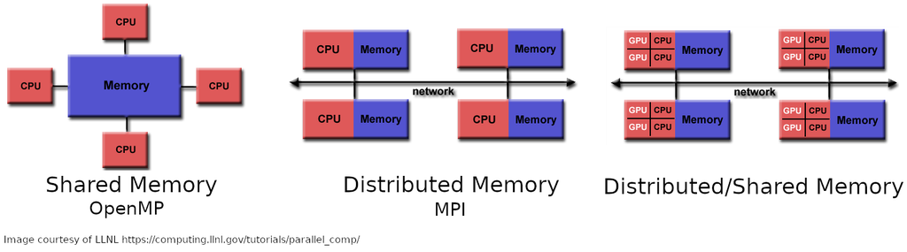

- A primer on the various jargon: node, core, processor, processes, tasks, etc.
- See also [here](https://smileipic.github.io/Smilei/parallelization.html)

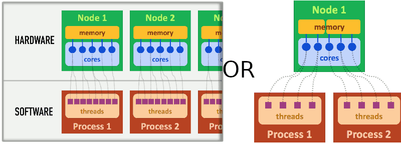

Example: Stampede2 (see also [documentation](https://portal.tacc.utexas.edu/user-guides/stampede2))

- 240 Intel "Ice Lake" (ICX) compute nodes, replacing 448 KNL compute nodes
- Knights Landing (KNL) compute nodes each have 68 cores
- Skylake (SKX) compute nodes each have 48 cores

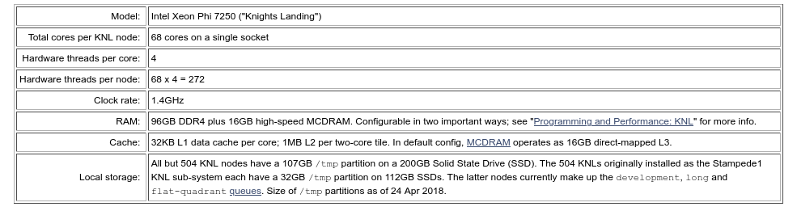

## Jobs on the supercomputer

Example: [Stampede2 at TACC](https://portal.tacc.utexas.edu/software/qe)

[figure not shown]

## Jobs on the supercomputer

Example: Logging into [Stampede2 at TACC](https://portal.tacc.utexas.edu/software/qe)

```bash
ssh -X <your-xsede-username>@stampede2.tacc.utexas.edu
```

```bash
The authenticity of host 'stampede2.tacc.utexas.edu (129.114.63.44)' can't be established.
ECDSA key fingerprint is SHA256:SegC2YyyftiRpdwhXqNZE+15RyGeFSal4Vuz0HYJ5E8.
Are you sure you want to continue connecting (yes/no/[fingerprint])? yes
Warning: Permanently added 'stampede2.tacc.utexas.edu,129.114.63.44' (ECDSA) to the list of known hosts.

To access the system:

1) If not using ssh-keys, please enter your TACC password at the password prompt
2) At the TACC Token prompt, enter your 6-digit code followed by <return>.
Password:
TACC Token Code:
Last login: Thu Feb 14 11:37:13 2019 from 149.165.168.51
------------------------------------------------------------------------------
                   Welcome to the Stampede2 Supercomputer
      Texas Advanced Computing Center, The University of Texas at Austin
------------------------------------------------------------------------------

              ** Unauthorized use/access is prohibited. **

If you log on to this computer system, you acknowledge your awareness
of and concurrence with the UT Austin Acceptable Use Policy. The
University will prosecute violators to the full extent of the law.

TACC Usage Policies:
http://www.tacc.utexas.edu/user-services/usage-policies/
______________________________________________________________________________

Welcome to Stampede2, *please* read these important system notes:

--> Stampede2 user documentation is available at:
       https://portal.tacc.utexas.edu/user-guides/stampede2

2/24/2022:  OS was updated to latest CentOS 7.9 release along with Slurm 20,
            OPA 10.11 and Lustre 2.12 updates.  Please submit a support ticket
            if you encounter any issues after the update.

            The icx-normal queue is now available for users, up to 40 nodes
            with 80 cores per node for a single job.
--------------------- Project balances for user wwwennie ----------------------
| Name           Avail SUs     Expires |                                      |
| TG-MAT220010        1600  2023-04-06 |                                      |
------------------------ Disk quotas for user wwwennie ------------------------
| Disk         Usage (GB)     Limit    %Used   File Usage       Limit   %Used |
| /home1              2.4      10.0    24.34         3541      200000    1.77 |
| /work2              0.0    1024.0     0.00            3     3000000    0.00 |
| /scratch            0.0       0.0     0.00           66           0    0.00 |
-------------------------------------------------------------------------------
```

## Jobs on the supercomputer

Example: [Stampede2 at TACC](https://portal.tacc.utexas.edu/software/qe)

job.script

```bash
#!/bin/bash
#SBATCH -J qe                               # define the job name
#SBATCH -o qe.%j.out                        # define stdout & stderr output files
#SBATCH -e qe.%j.err
#SBATCH -N 4                                # request 4 nodes
#SBATCH -n 256                              # 256 total tasks = 64 tasks/node
#SBATCH -p normal                           # submit to "normal" queue
#SBATCH -t 4:00:00                          # run for 4 hours max
#SBATCH -A projectname

module load qe/6.2.1                        # setup environment
ibrun pw.x -input qeinput > qe_test.out     # launch job
```

```bash
sbatch job.script
```

## Parallelization in DFT codes

- Every code has a scheme of parallelization- it is important to understand what these levels are and how well they perform
- The goal is to load balance so that no cores are unnecessarily idle

## Parallelization in DFT codes

Example: Quantum ESPRESSO

```bash
mpirun -np 4096 ./neb.x -ni 8 -nk 2 -nt 4 -nd 144 -i my.input
```

## What are scaling tests

Goal: find the parallelization with most efficient use of resources

How do you choose the parallelization parameters?

--> Reading documentation/forums, doing tutorials and small test cases, doing scaling tests!

Scaling tests: extrapolating resource usage efficiency based on small tests of parallelization schemes

## Why we do scaling tests

- DFT codes scale with $O(N^3)$ where $N$ is some measure of system size (e.g., number of electrons, number of bands)
- In general, not all parts of a DFT calculation scales linearly with processors
- A simulation cell of about 100 atoms could take anywhere between a few hours to a few weeks (e.g., depending on functional)

## Why we do scaling tests

- Not enough parallelization: wait too long for calculatoin to finish
- Improper parallelization: waste of hours (and energy!)

## How do we do scaling tests

1. set up a working calculation that is representative of the calculations you anticipate for the project
2. enumerate a few parallelization schemes
3. run the minimum calculation needed
- e.g., single scf cycle, extrapolate to number needed for atomic relaxation
- e.g., single q-point phonone mode calculation, extrapolate to entire q-point mesh
4. collect data, visualize, and pick a scheme

## Example: Scaling test

- Comparing WO$_3$ and SrTiO$_3$ electron transport properties
- do tests with and without spin-orbit coupling
- need to compute many phonons on a dense grid
- find out time to compute one phonon; repeat for all cases of WO$_3$ and SrTiO$_3$
- Paper: [link](https://dx.doi.org/10.1103/PhysRevB.101.045116)

## Example: Scaling test

- One way to automate the scaling test (but first, try a few test cases!)

set_scaling.sh

```bash
#!/bin/bash

proc=(144 160 320)
npool=(2 4 6 8)

for i in "${proc[@]}"; do
   for j in "${npool[@]}"; do
       mkdir p${i}n${j}
       cd p${i}n${j}

       # copy template input files
       cp -r ../input.in ../*UPF ../phrun.sh .

       # substitute parallelization into run command
       # of a template job submission script called phrun.sh
       sed -i "s/REPL1/${i}/g" phrun.sh
       sed -i "s/REPL2/${j}/g" phrun.sh
       cd ../
   done
done
```

```bash
wwwennie@stampede2 scaling-test $ ls
p144n2  p144n4  p144n6  p144n8  p160n2  p160n4  p160n6  p160n8  p320n2  p320n4  p320n6  p320n8  set_scaling.sh
```

## Example: Scaling test

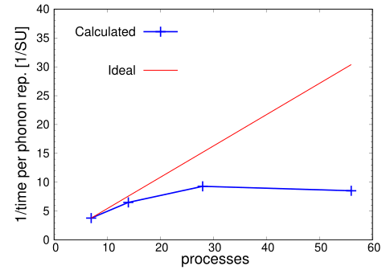

## Writing up scaling tests

- Progress Report (if relevant)
- Scientific Research Objective: What is the goal of the calculation?
- Computational Methodology, Applications/Codes
- Application efficiencies
- Computational Research Plan
- Justification of computer SUs and memory requirements

## Writing up scaling tests

- aim to do tests on anticipate machine architecture
- add some buffer to the hours requested- failed jobs, testing of parameters not known at time of scaling tests, etc.

[Group wiki: Example write up](https://wikis.utexas.edu/download/attachments/360416757/XSEDE2018-WW.pdf?version=1&modificationDate=1653437358790&api=v2)